# Cyclistic_Analysis

Fahad

3/7/2022

## Cyclistic

Install needed packages

```r
  library(tidyverse)
  library(lubridate)
```

Import data

```r
  setwd("D:/Capstone/Data")
  trip_data_2021_02 <- read.csv("202102-divvy-tripdata.csv")
  trip_data_2021_03 <- read.csv("202103-divvy-tripdata.csv")
  trip_data_2021_04 <- read.csv("202104-divvy-tripdata.csv")
  trip_data_2021_05 <- read.csv("202105-divvy-tripdata.csv")
  trip_data_2021_06 <- read.csv("202106-divvy-tripdata.csv")
  trip_data_2021_07 <- read.csv("202107-divvy-tripdata.csv")
  trip_data_2021_08 <- read.csv("202108-divvy-tripdata.csv")
  trip_data_2021_09 <- read.csv("202109-divvy-tripdata.csv")
  trip_data_2021_10 <- read.csv("202110-divvy-tripdata.csv")
  trip_data_2021_11 <- read.csv("202111-divvy-tripdata.csv")
  trip_data_2021_12 <- read.csv("202112-divvy-tripdata.csv")
  trip_data_2022_01 <- read.csv("202201-divvy-tripdata.csv")
```

Check column names to ensure we can join all the data

```r
  colnames(trip_data_2021_02)
```

```
##  [1] "ride_id"            "rideable_type"      "started_at"
##  [4] "ended_at"           "start_station_name" "start_station_id"
##  [7] "end_station_name"   "end_station_id"     "start_lat"
## [10] "start_lng"          "end_lat"            "end_lng"
## [13] "member_casual"
```

```r
  colnames(trip_data_2021_03)
```

```
##  [1] "ride_id"            "rideable_type"      "started_at"
##  [4] "ended_at"           "start_station_name" "start_station_id"
##  [7] "end_station_name"   "end_station_id"     "start_lat"
## [10] "start_lng"          "end_lat"            "end_lng"
## [13] "member_casual"
```

```r
  colnames(trip_data_2021_04)
```

```
##  [1] "ride_id"            "rideable_type"      "started_at"
##  [4] "ended_at"           "start_station_name" "start_station_id"
##  [7] "end_station_name"   "end_station_id"     "start_lat"
## [10] "start_lng"          "end_lat"            "end_lng"
## [13] "member_casual"
```

```r
  colnames(trip_data_2021_05)
```

```
##  [1] "ride_id"            "rideable_type"      "started_at"
##  [4] "ended_at"           "start_station_name" "start_station_id"
##  [7] "end_station_name"   "end_station_id"     "start_lat"
## [10] "start_lng"          "end_lat"            "end_lng"
## [13] "member_casual"
```

```r
  colnames(trip_data_2021_06)
```

```
##  [1] "ride_id"            "rideable_type"      "started_at"
##  [4] "ended_at"           "start_station_name" "start_station_id"
##  [7] "end_station_name"   "end_station_id"     "start_lat"
## [10] "start_lng"          "end_lat"            "end_lng"
## [13] "member_casual"
```

```r
  colnames(trip_data_2021_07)
```

```
##  [1] "ride_id"            "rideable_type"      "started_at"
##  [4] "ended_at"           "start_station_name" "start_station_id"
##  [7] "end_station_name"   "end_station_id"     "start_lat"
## [10] "start_lng"          "end_lat"            "end_lng"
## [13] "member_casual"
```

```r
  colnames(trip_data_2021_08)
```

```
##  [1] "ride_id"            "rideable_type"      "started_at"
##  [4] "ended_at"           "start_station_name" "start_station_id"
##  [7] "end_station_name"   "end_station_id"     "start_lat"
## [10] "start_lng"          "end_lat"            "end_lng"
## [13] "member_casual"
```

```r
  colnames(trip_data_2021_09)
```

```
##  [1] "ride_id"            "rideable_type"      "started_at"
##  [4] "ended_at"           "start_station_name" "start_station_id"
##  [7] "end_station_name"   "end_station_id"     "start_lat"
## [10] "start_lng"          "end_lat"            "end_lng"
## [13] "member_casual"
```

```r
  colnames(trip_data_2021_10)
```

```
##  [1] "ride_id"            "rideable_type"      "started_at"
##  [4] "ended_at"           "start_station_name" "start_station_id"
##  [7] "end_station_name"   "end_station_id"     "start_lat"
## [10] "start_lng"          "end_lat"            "end_lng"
## [13] "member_casual"
```

```r
  colnames(trip_data_2021_11)
```

```
##  [1] "ride_id"            "rideable_type"      "started_at"
##  [4] "ended_at"           "start_station_name" "start_station_id"
##  [7] "end_station_name"   "end_station_id"     "start_lat"
## [10] "start_lng"          "end_lat"            "end_lng"
## [13] "member_casual"
```

```r
  colnames(trip_data_2021_12)
```

```
##  [1] "ride_id"            "rideable_type"      "started_at"
##  [4] "ended_at"           "start_station_name" "start_station_id"
##  [7] "end_station_name"   "end_station_id"     "start_lat"
## [10] "start_lng"          "end_lat"            "end_lng"
## [13] "member_casual"
```

```r
  colnames(trip_data_2022_01)
```

```
##  [1] "ride_id"            "rideable_type"      "started_at"
##  [4] "ended_at"           "start_station_name" "start_station_id"
##  [7] "end_station_name"   "end_station_id"     "start_lat"
## [10] "start_lng"          "end_lat"            "end_lng"
## [13] "member_casual"
```

Combine data into one set.

```r
all_trips <- rbind(trip_data_2021_02, trip_data_2021_03, trip_data_2021_04, trip_data_2021_05, trip_data_2021_06, trip_data_2021_07, trip_data_2021_08, trip_data_2021_09, trip_data_2021_10, trip_data_2021_11, trip_data_2021_12, trip_data_2022_01)
```

Inspect data to find cleaning opportunities

```r
colnames(all_trips)
```

```
##  [1] "ride_id"            "rideable_type"      "started_at"
##  [4] "ended_at"           "start_station_name" "start_station_id"
##  [7] "end_station_name"   "end_station_id"     "start_lat"
## [10] "start_lng"          "end_lat"            "end_lng"
## [13] "member_casual"
```

```r
nrow(all_trips)
```

```
## [1] 5601999
```

```r
dim(all_trips)
```

```
## [1] 5601999      13
```

```r
head(all_trips)
```

```
##            ride_id rideable_type          started_at            ended_at
## 1 89E7AA6C29227EFF  classic_bike 2021-02-12 16:14:56 2021-02-12 16:21:43
## 2 0FEFDE2603568365  classic_bike 2021-02-14 17:52:38 2021-02-14 18:12:09
## 3 E6159D746B2DBB91 electric_bike 2021-02-09 19:10:18 2021-02-09 19:19:10
## 4 B32D3199F1C2E75B  classic_bike 2021-02-02 17:49:41 2021-02-02 17:54:06
## 5 83E463F23575F4BF electric_bike 2021-02-23 15:07:23 2021-02-23 15:22:37
## 6 BDAA7E3494E8D545 electric_bike 2021-02-24 15:43:33 2021-02-24 15:49:05
##           start_station_name start_station_id           end_station_name
## 1   Glenwood Ave & Touhy Ave              525 Sheridan Rd & Columbia Ave
## 2   Glenwood Ave & Touhy Ave              525   Bosworth Ave & Howard St
## 3         Clark St & Lake St     KA1503000012     State St & Randolph St
## 4      Wood St & Chicago Ave              637    Honore St & Division St
## 5         State St & 33rd St            13216      Emerald Ave & 31st St
## 6 Fairbanks St & Superior St            18003      LaSalle Dr & Huron St
##   end_station_id start_lat start_lng  end_lat   end_lng member_casual
## 1            660  42.01270 -87.66606 42.00458 -87.66141        member
## 2          16806  42.01270 -87.66606 42.01954 -87.66956        casual
## 3   TA1305000029  41.88579 -87.63110 41.88487 -87.62750        member
## 4   TA1305000034  41.89563 -87.67207 41.90312 -87.67394        member
## 5   TA1309000055  41.83473 -87.62583 41.83816 -87.64512        member
## 6   KP1705001026  41.89581 -87.62025 41.89489 -87.63198        casual
```

```r
tail(all_trips)
```

```
##                  ride_id rideable_type          started_at            ended_at
## 5601994 9C80CD03B685B1B4 electric_bike 2022-01-09 18:56:50 2022-01-09 19:02:50
## 5601995 8788DA3EDE8FD8AB electric_bike 2022-01-18 12:36:48 2022-01-18 12:46:19
## 5601996 C6C3B64FDC827D8C electric_bike 2022-01-27 11:00:06 2022-01-27 11:02:40
## 5601997 CA281AE7D8B06F5A electric_bike 2022-01-10 16:14:51 2022-01-10 16:20:58
## 5601998 44E348991862319B electric_bike 2022-01-19 13:22:11 2022-01-19 13:24:27
## 5601999 E477C594A182AE58 electric_bike 2022-01-13 17:24:43 2022-01-13 17:28:14
##                   start_station_name start_station_id          end_station_name
## 5601994      Broadway & Waveland Ave            13325
## 5601995 Clinton St & Washington Blvd           WL-012
## 5601996     Racine Ave & Randolph St            13155
## 5601997      Broadway & Waveland Ave            13325       Clark St & Grace St
## 5601998     Racine Ave & Randolph St            13155
## 5601999 Clinton St & Washington Blvd           WL-012 Desplaines St & Kinzie St
##         end_station_id start_lat start_lng  end_lat   end_lng member_casual
## 5601994                 41.94904 -87.64850 41.93000 -87.64000        casual
## 5601995                 41.88344 -87.64139 41.89000 -87.62000        casual
## 5601996                 41.88416 -87.65698 41.88000 -87.65000        casual
## 5601997   TA1307000127  41.94907 -87.64861 41.95078 -87.65917        casual
## 5601998                 41.88401 -87.65703 41.88000 -87.66000        casual
## 5601999   TA1306000003  41.88325 -87.64124 41.88872 -87.64445        casual
```

```r
str(all_trips)
```

```
## 'data.frame':    5601999 obs. of  13 variables:
##  $ ride_id           : chr  "89E7AA6C29227EFF" "0FEFDE2603568365" "E6159D746B2DBB91" "B32D3199F1C2E75B" ...
##  $ rideable_type     : chr  "classic_bike" "classic_bike" "electric_bike" "classic_bike" ...
##  $ started_at        : chr  "2021-02-12 16:14:56" "2021-02-14 17:52:38" "2021-02-09 19:10:18" "2021-02-02 17:49:41" ...
##  $ ended_at          : chr  "2021-02-12 16:21:43" "2021-02-14 18:12:09" "2021-02-09 19:19:10" "2021-02-02 17:54:06" ...
##  $ start_station_name: chr  "Glenwood Ave & Touhy Ave" "Glenwood Ave & Touhy Ave" "Clark St & Lake St" "Wood St & Chicago Ave" ...
##  $ start_station_id  : chr  "525" "525" "KA1503000012" "637" ...
##  $ end_station_name  : chr  "Sheridan Rd & Columbia Ave" "Bosworth Ave & Howard St" "State St & Randolph St" "Honore St & Division St" ...
##  $ end_station_id    : chr  "660" "16806" "TA1305000029" "TA1305000034" ...
##  $ start_lat         : num  42 42 41.9 41.9 41.8 ...
##  $ start_lng         : num  -87.7 -87.7 -87.6 -87.7 -87.6 ...
##  $ end_lat           : num  42 42 41.9 41.9 41.8 ...
##  $ end_lng           : num  -87.7 -87.7 -87.6 -87.7 -87.6 ...
##  $ member_casual     : chr  "member" "casual" "member" "member" ...
```

```r
summary(all_trips)
```

```
##    ride_id          rideable_type       started_at          ended_at
##  Length:5601999     Length:5601999     Length:5601999     Length:5601999
##  Class :character   Class :character   Class :character   Class :character
##  Mode  :character   Mode  :character   Mode  :character   Mode  :character
##
##
##
##
##  start_station_name start_station_id   end_station_name   end_station_id
##  Length:5601999     Length:5601999     Length:5601999     Length:5601999
##  Class :character   Class :character   Class :character   Class :character
##  Mode  :character   Mode  :character   Mode  :character   Mode  :character
##
##
##
##
##    start_lat       start_lng         end_lat         end_lng
##  Min.   :41.64   Min.   :-87.84   Min.   :41.39   Min.   :-88.97
##  1st Qu.:41.88   1st Qu.:-87.66   1st Qu.:41.88   1st Qu.:-87.66
##  Median :41.90   Median :-87.64   Median :41.90   Median :-87.64
##  Mean   :41.90   Mean   :-87.65   Mean   :41.90   Mean   :-87.65
##  3rd Qu.:41.93   3rd Qu.:-87.63   3rd Qu.:41.93   3rd Qu.:-87.63
##  Max.   :45.64   Max.   :-73.80   Max.   :42.17   Max.   :-87.49
##                                   NA's   :4754    NA's   :4754
##  member_casual
##  Length:5601999
##  Class :character
##  Mode  :character
##
##
##
##
```

```r
table(all_trips$start_station_name)
```

[output not shown]

[output cut: 1644 more lines]

```
##                                                 16757
##                            Wood St & Taylor St (Temp)
##                                                  7181
##      Woodlawn & 103rd - Olive Harvey Vaccination Site
##                                                    52
##                                Woodlawn Ave & 55th St
##                                                  7821
##                                Woodlawn Ave & 75th St
##                                                    67
##                          Woodlawn Ave & Lake Park Ave
##                                                  1830
##                                  Yates Blvd & 75th St
##                                                   215
##                                  Yates Blvd & 93rd St
##                                                   149
```

```r
table(all_trips$rideable_type)
```

```
##
##  classic_bike   docked_bike electric_bike
##       3244395        311198       2046406
```

Note stations “DIVVY CASSETTE REPAIR MOBILE STATION” and “HUBBARD ST BIKE CHECKING (LBS-WH-TEST)”

Add columns for date, month, day and year of each ride

```r
all_trips$date <- as.Date(all_trips$started_at)
all_trips$month <- format(as.Date(all_trips$date), "%m")
all_trips$day <- format(as.Date(all_trips$date), "%d")
all_trips$year <- format(as.Date(all_trips$date), "%Y")
all_trips$day_of_week <- format(as.Date(all_trips$date), "%A")
```

Add ride_length calculation in seconds and convert to number

```r
all_trips$ride_length <- difftime(all_trips$ended_at,all_trips$started_at)
all_trips$ride_length <- as.numeric(as.character(all_trips$ride_length))
```

Check for anomalies in ride_length data

```r
summary(all_trips$ride_length)
```

```
##    Min. 1st Qu.  Median    Mean 3rd Qu.    Max.
##   -3482     403     717    1316    1303 3356649
```

Remove bad data and put into v2 dataframe (less than 60 seconds, test or repair station, docked bikes)

```r
all_trips_v2 <- all_trips[!(all_trips$start_station_name == "DIVVY CASSETTE REPAIR MOBILE STATION" | all_trips$start_station_name == "HUBBARD ST BIKE CHECKING (LBS-WH-TEST)" | all_trips$rideable_type == "docked_bike" | all_trips$ride_length < 60),]
```

Double check for anomalies

```r
summary(all_trips_v2$ride_length)
```

```
##    Min. 1st Qu.  Median    Mean 3rd Qu.    Max.
##      60     403     698    1121    1234   93596
```

Compare members vs casuals

```r
aggregate(all_trips_v2$ride_length ~ all_trips_v2$member_casual, FUN = mean)
```

```
##   all_trips_v2$member_casual all_trips_v2$ride_length
## 1                     casual                1523.2166
## 2                     member                 829.9112
```

```r
aggregate(all_trips_v2$ride_length ~ all_trips_v2$member_casual, FUN = median)
```

```
##   all_trips_v2$member_casual all_trips_v2$ride_length
## 1                     casual                      898
## 2                     member                      583
```

```r
aggregate(all_trips_v2$ride_length ~ all_trips_v2$member_casual, FUN = max)
```

```
##   all_trips_v2$member_casual all_trips_v2$ride_length
## 1                     casual                    93596
## 2                     member                    93596
```

```r
aggregate(all_trips_v2$ride_length ~ all_trips_v2$member_casual, FUN = min)
```

```
##   all_trips_v2$member_casual all_trips_v2$ride_length
## 1                     casual                       60
## 2                     member                       60
```

Correct order for day of the week

```r
all_trips_v2$day_of_week <- ordered(all_trips_v2$day_of_week, levels=c("Sunday", "Monday", "Tuesday", "Wednesday", "Thursday", "Friday", "Saturday"))
```

Average ride time for members vs casuals

```r
aggregate(all_trips_v2$ride_length ~ all_trips_v2$member_casual + all_trips_v2$day_of_week, FUN = mean)
```

```
##    all_trips_v2$member_casual all_trips_v2$day_of_week all_trips_v2$ride_length
## 1                      casual                   Sunday                1759.7774
## 2                      member                   Sunday                 956.2601
## 3                      casual                   Monday                1537.2281
## 4                      member                   Monday                 804.3986
## 5                      casual                  Tuesday                1371.5665
## 6                      member                  Tuesday                 779.1482
## 7                      casual                Wednesday                1330.6057
## 8                      member                Wednesday                 778.3655
## 9                      casual                 Thursday                1337.7163
## 10                     member                 Thursday                 777.0901
## 11                     casual                   Friday                1428.9724
## 12                     member                   Friday                 812.2314
## 13                     casual                 Saturday                1655.6030
## 14                     member                 Saturday                 931.0295
```

Rides by member vs casual and weekday

```r
all_trips_v2 %>%
  mutate(weekday = wday(started_at, label = TRUE)) %>%
  group_by(member_casual, weekday) %>%
  summarise(number_of_rides = n()
  ,average_duration = mean(ride_length)) %>%
  arrange(member_casual, weekday)
```

```
## # A tibble: 14 x 4
## # Groups:   member_casual [2]
##    member_casual weekday number_of_rides average_duration
##    <chr>         <ord>             <int>            <dbl>
##  1 casual        Sun              404380            1760.
##  2 casual        Mon              246750            1537.
##  3 casual        Tue              241897            1372.
##  4 casual        Wed              248083            1331.
##  5 casual        Thu              255136            1338.
##  6 casual        Fri              317111            1429.
##  7 casual        Sat              472580            1656.
##  8 member        Sun              369318             956.
##  9 member        Mon              411513             804.
## 10 member        Tue              461247             779.
## 11 member        Wed              471115             778.
## 12 member        Thu              446437             777.
## 13 member        Fri              437700             812.
## 14 member        Sat              423800             931.
```

Show number of rides by rider type

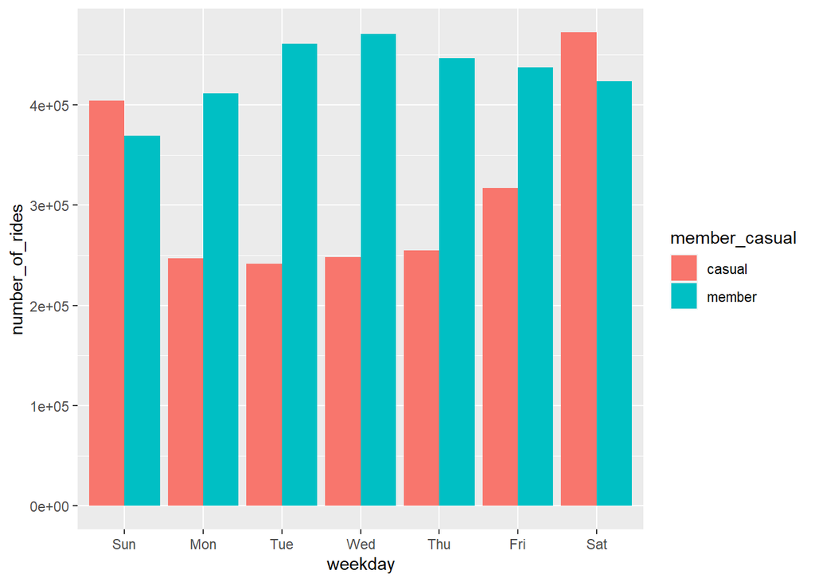

```r
all_trips_v2 %>%
  mutate(weekday = wday(started_at, label = TRUE)) %>%
  group_by(member_casual, weekday) %>%
  summarise(number_of_rides = n()
            ,average_duration = mean(ride_length)) %>%
  arrange(member_casual, weekday)  %>%
  ggplot(aes(x = weekday, y = number_of_rides, fill = member_casual)) +
  geom_col(position = "dodge")
```

Show average duration

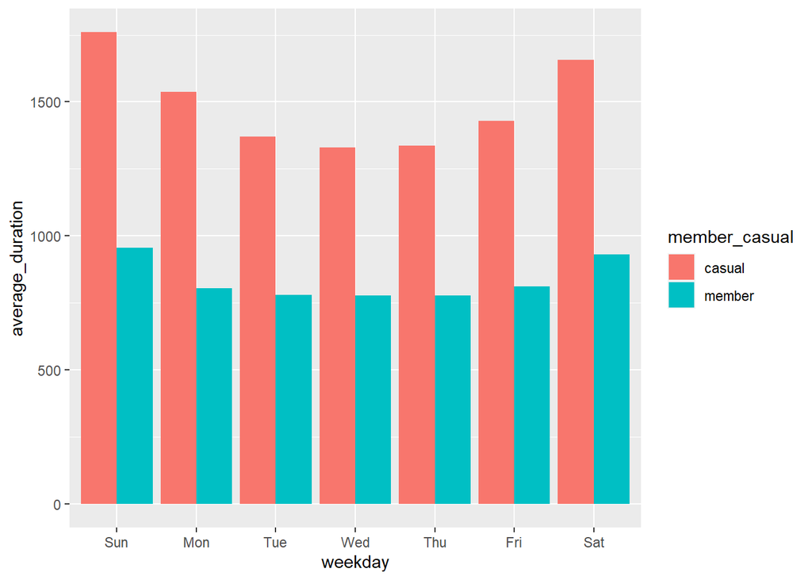

```r
all_trips_v2 %>%
  mutate(weekday = wday(started_at, label = TRUE)) %>%
  group_by(member_casual, weekday) %>%
  summarise(number_of_rides = n()
            ,average_duration = mean(ride_length)) %>%
  arrange(member_casual, weekday)  %>%
  ggplot(aes(x = weekday, y = average_duration, fill = member_casual)) +
  geom_col(position = "dodge")
```

Find only rides longer than one day per rider type

```r
long_trips <- all_trips_v2[(all_trips_v2$ride_length >= 86400),]
```

Show trips more than one day per rider type

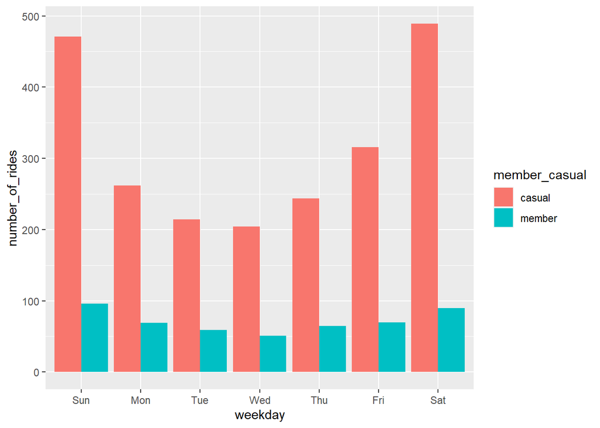

```r
long_trips %>%
  mutate(weekday = wday(started_at, label = TRUE)) %>%
  group_by(member_casual, weekday) %>%
  summarise(number_of_rides = n()
            ,average_duration = mean(ride_length)) %>%
  arrange(member_casual, weekday)  %>%
  ggplot(aes(x = weekday, y = number_of_rides, fill = member_casual)) +
  geom_col(position = "dodge")
```

Export summary files for further analysis

```r
counts <- aggregate(all_trips_v2$ride_length ~ all_trips_v2$member_casual + all_trips_v2$day_of_week, FUN = mean)
write.csv(counts, file = 'D:/Capstone/Data/avg_ride_length.csv')
```

```r
long_counts <- aggregate(long_trips$ride_length ~ long_trips$member_casual + long_trips$day_of_week, FUN = length)
write.csv(long_counts, file = 'D:/Capstone/Data/long_ride_length.csv')
```

```r
ride_counts <- aggregate(all_trips_v2$ride_length ~ all_trips_v2$member_casual + all_trips_v2$day_of_week, FUN = length)
write.csv(ride_counts, file = 'D:/Capstone/Data/number_of_rides.csv')
```